# MovieLens Project Question Notebook

### `Project - MovieLens Data Analysis`

The GroupLens Research Project is a research group in the Department of Computer Science and Engineering at the University of Minnesota. The data is widely used for collaborative filtering and other filtering solutions. However, we will be using this data to act as a means to demonstrate our skill in using Python to “play” with data.

### `Objective:`

- To implement the techniques learnt as a part of the course.

### `Datasets Information:`

*rating.csv:* It contains information on ratings given by the users to a particular movie.

- user id: id assigned to every user
- movie id: id assigned to every movie
- rating: rating given by the user
- timestamp: Time recorded when the user gave a rating

*movie.csv:* File contains information related to the movies and their genre.

- movie id: id assigned to every movie
- movie title: Title of the movie
- release date: Date of release of the movie
- Action: Genre containing binary values (1 - for action 0 - not action)
- Adventure: Genre containing binary values (1 - for adventure 0 - not adventure)
- Animation: Genre containing binary values (1 - for animation 0 - not animation)
- Children’s: Genre containing binary values (1 - for children's 0 - not children's)
- Comedy: Genre containing binary values (1 - for comedy 0 - not comedy)
- Crime: Genre containing binary values (1 - for crime 0 - not crime)
- Documentary: Genre containing binary values (1 - for documentary 0 - not documentary)
- Drama: Genre containing binary values (1 - for drama 0 - not drama)
- Fantasy: Genre containing binary values (1 - for fantasy 0 - not fantasy)
- Film-Noir: Genre containing binary values (1 - for film-noir 0 - not film-noir)
- Horror: Genre containing binary values (1 - for horror 0 - not horror)
- Musical: Genre containing binary values (1 - for musical 0 - not musical)
- Mystery: Genre containing binary values (1 - for mystery 0 - not mystery)
- Romance: Genre containing binary values (1 - for romance 0 - not romance)
- Sci-Fi: Genre containing binary values (1 - for sci-fi 0 - not sci-fi)
- Thriller: Genre containing binary values (1 - for thriller 0 - not thriller)
- War: Genre containing binary values (1 - for war 0 - not war)
- Western: Genre containing binary values (1 - for western - not western)

*user.csv:* It contains information of the users who have rated the movies.

- user id: id assigned to every user
- age: Age of the user
- gender: Gender of the user
- occupation: Occupation of the user
- zip code: Zip code of the use

**`Please provide your insights wherever necessary.`**

### `Learning Outcomes:`

- Exploratory Data Analysis
- Visualization using Python
- Pandas – groupby, merging

### `Domain`

- Internet and Entertainment

**Note that the project will need you to apply the concepts of groupby and merging extensively.**

### 1. Import the necessary packages - 2.5 marks

```python
#your code here
#library imports
import pandas as pd
import numpy as np
import matplotlib.pyplot as plt
import seaborn as sns
sns.set(color_codes=True)   # supports use of color codes
%matplotlib inline

from IPython.core.display import display, HTML
display(HTML("<style>div.output_scroll { width:100%; height: 50em; }</style>"))  # increase cell width and height
```

### 2. Read the 3 datasets into dataframes - 2.5 marks

```python
#your code here
# Read input data into pandas data frame
rating = pd.read_csv("Data.csv")
user = pd.read_csv("user.csv")
movie = pd.read_csv("item.csv")
```

### 3. Apply info, shape, describe, and find the number of missing values in the data. Present at least 3 observations from these operations - 2.5 marks

- Note that you will need to do it for all the three datasets seperately

```python
#your code here
## Movie data description

print('Movie Data:')
print('=============')
print('Shape: ',movie.shape)
print('Number of NULL values: ',movie.isnull().sum().sum())
print('Index: ',movie.index)
print('Movie id minimum value: ',movie['movie id'].min())
print('Movie id maximum value: ',movie['movie id'].max())
print('\ncolumns data types counts:\n ',user.dtypes.value_counts())
print('\ncolumns data types:\n',user.dtypes)
print('\n')

print(movie.info())
print('\n')

print(movie.describe().T)
print('\n')


#Observations
# 1. There are no null values
# 2. Movie Id values start from 1( not 0) .  that is minimum movie id is 1
# 3. Looks like there is missing id in the movie id columns
#    because index min,max is (0,1680) so max_id (as the ids are continuos) should be 1681. but max id is 1682.
# 4. Looks like we have more number of Drama genre movies as the mean(Drama) is more.
```

```
Movie Data:
=============
Shape:  (1681, 22)
Number of NULL values:  0
Index:  RangeIndex(start=0, stop=1681, step=1)
Movie id minimum value:  1
Movie id maximum value:  1682

columns data types counts:
  object    3
int64     2
dtype: int64

columns data types:
 user id        int64
age            int64
gender        object
occupation    object
zip code      object
dtype: object


<class 'pandas.core.frame.DataFrame'>
RangeIndex: 1681 entries, 0 to 1680
Data columns (total 22 columns):
 #   Column        Non-Null Count  Dtype
---  ------        --------------  -----
 0   movie id      1681 non-null   int64
 1   movie title   1681 non-null   object
 2   release date  1681 non-null   object
 3   unknown       1681 non-null   int64
 4   Action        1681 non-null   int64
 5   Adventure     1681 non-null   int64
 6   Animation     1681 non-null   int64
 7   Childrens     1681 non-null   int64
 8   Comedy        1681 non-null   int64
 9   Crime         1681 non-null   int64
 10  Documentary   1681 non-null   int64
 11  Drama         1681 non-null   int64
 12  Fantasy       1681 non-null   int64
```

[output cut: 20 more lines]

```
Childrens    1681.0    0.072576    0.259516  0.0    0.0    0.0     0.0     1.0
Comedy       1681.0    0.300416    0.458576  0.0    0.0    0.0     1.0     1.0
Crime        1681.0    0.064842    0.246321  0.0    0.0    0.0     0.0     1.0
Documentary  1681.0    0.029744    0.169931  0.0    0.0    0.0     0.0     1.0
Drama        1681.0    0.431291    0.495404  0.0    0.0    0.0     1.0     1.0
Fantasy      1681.0    0.013087    0.113683  0.0    0.0    0.0     0.0     1.0
Film-Noir    1681.0    0.014277    0.118667  0.0    0.0    0.0     0.0     1.0
Horror       1681.0    0.054729    0.227519  0.0    0.0    0.0     0.0     1.0
Musical      1681.0    0.033314    0.179507  0.0    0.0    0.0     0.0     1.0
Mystery      1681.0    0.036288    0.187061  0.0    0.0    0.0     0.0     1.0
Romance      1681.0    0.146936    0.354148  0.0    0.0    0.0     0.0     1.0
Sci-Fi       1681.0    0.060083    0.237712  0.0    0.0    0.0     0.0     1.0
Thriller     1681.0    0.149316    0.356506  0.0    0.0    0.0     0.0     1.0
War          1681.0    0.042237    0.201189  0.0    0.0    0.0     0.0     1.0
Western      1681.0    0.016062    0.125751  0.0    0.0    0.0     0.0     1.0
```

```python
print("User Data")
print("============")

print('Shape: ',user.shape)
print('Number of NULL values: ',user.isnull().sum().sum())
print('Index: ',user.index)
print('User id minimum value: ',user['user id'].min())
print('User id maximum value: ',user['user id'].max())
print('Distinct Occupation values: ',user['occupation'].unique())


print('\ncolumns data types counts\n',user.dtypes.value_counts())
print('\ncolumns data types\n',user.dtypes)
print('\n')

print(user.info())
print('\n')

print(user.describe().T)
print('\n')



#Observations

#1. There are no null values
#2. There are 2 int type columns and 3 object type columns.
#3. Even though zip code is numeric, the column zip code data type is object type.
#4. Age column looks like right skewed because mean is greater than median.
#5. Few rows have occupation as 'other','none'.
```

```
User Data
============
Shape:  (943, 5)
Number of NULL values:  0
Index:  RangeIndex(start=0, stop=943, step=1)
User id minimum value:  1
User id maximum value:  943
Distinct Occupation values:  ['technician' 'other' 'writer' 'executive' 'administrator' 'student'
 'lawyer' 'educator' 'scientist' 'entertainment' 'programmer' 'librarian'
 'homemaker' 'artist' 'engineer' 'marketing' 'none' 'healthcare' 'retired'
 'salesman' 'doctor']

columns data types counts
 object    3
int64     2
dtype: int64

columns data types
 user id        int64
age            int64
gender        object
occupation    object
zip code      object
dtype: object


<class 'pandas.core.frame.DataFrame'>
RangeIndex: 943 entries, 0 to 942
Data columns (total 5 columns):
 #   Column      Non-Null Count  Dtype
---  ------      --------------  -----
 0   user id     943 non-null    int64
 1   age         943 non-null    int64
 2   gender      943 non-null    object
 3   occupation  943 non-null    object
 4   zip code    943 non-null    object
dtypes: int64(2), object(3)
memory usage: 37.0+ KB
None


         count        mean         std  min    25%    50%    75%    max
user id  943.0  472.000000  272.364951  1.0  236.5  472.0  707.5  943.0
age      943.0   34.051962   12.192740  7.0   25.0   31.0   43.0   73.0
```

```python
print("Rating Data")
print("============")
print('Shape: ',rating.shape)
print('Number of NULL values: ',rating.isnull().sum().sum())
print('Index: ',rating.index)
print('\ncolumns data types counts\n',rating.dtypes.value_counts())
print('\ncolumns data types\n',rating.dtypes)

print('\n')
print(rating.info())
print('\n')

print(rating.describe())

#Observations:
#1. There are no null values
#2. All columns are integer type.
#3. Time stamp column is also interger . Time not given in date-time fromat.
#4. Ratings are left skewed or -ve skewed.
```

```
Rating Data
============
Shape:  (100000, 4)
Number of NULL values:  0
Index:  RangeIndex(start=0, stop=100000, step=1)

columns data types counts
 int64    4
dtype: int64

columns data types
 user id      int64
movie id     int64
rating       int64
timestamp    int64
dtype: object


<class 'pandas.core.frame.DataFrame'>
RangeIndex: 100000 entries, 0 to 99999
Data columns (total 4 columns):
 #   Column     Non-Null Count   Dtype
---  ------     --------------   -----
 0   user id    100000 non-null  int64
 1   movie id   100000 non-null  int64
 2   rating     100000 non-null  int64
 3   timestamp  100000 non-null  int64
dtypes: int64(4)
memory usage: 3.1 MB
None


            user id       movie id         rating     timestamp
count  100000.00000  100000.000000  100000.000000  1.000000e+05
mean      462.48475     425.530130       3.529860  8.835289e+08
std       266.61442     330.798356       1.125674  5.343856e+06
min         1.00000       1.000000       1.000000  8.747247e+08
25%       254.00000     175.000000       3.000000  8.794487e+08
50%       447.00000     322.000000       4.000000  8.828269e+08
75%       682.00000     631.000000       4.000000  8.882600e+08
max       943.00000    1682.000000       5.000000  8.932866e+08
```

**Observations:**

**Movie data set:**

1. There are no null values
2. Movie Id values start from 1( not 0) . that is minimum movie id is 1
3. Looks like there is missing id in the movie id columns because index min,max is (0,1680) so max_id (as the ids are continuos) should be 1681. but max id is 1682.
4. Looks like we have more number of Drama genre movies as the mean(Drama) is more.

**User data set:**

1. There are no null values
2. There are 2 int type columns and 3 object type columns.
3. Even though zip code is numeric, the column zip code data type is object type.
4. Age column looks like right skewed because mean is greater than median .
5. Few rows have occupation as 'other','none'.

**Rating data set**

1. there are no null values
2. All columns are integer type.
3. Time stamp column is also interger . Time not given in date-time fromat.
4. Ratings are left skewed or -ve skewed.

### 4. Find the number of movies per genre using the item data - 2.5 marks

```python
#your code here
genre_columns =['unknown', 'Action',
       'Adventure', 'Animation', 'Childrens', 'Comedy', 'Crime', 'Documentary',
       'Drama', 'Fantasy', 'Film-Noir', 'Horror', 'Musical', 'Mystery',
       'Romance', 'Sci-Fi', 'Thriller', 'War', 'Western']  # created list of genres column names to facilitate interation

print("Number of movies per genre:")

for col in genre_columns:
    print(col," :",movie[col].value_counts()[1])  # movie count for each genre.
```

```
Number of movies per genre:
unknown  : 1
Action  : 251
Adventure  : 135
Animation  : 42
Childrens  : 122
Comedy  : 505
Crime  : 109
Documentary  : 50
Drama  : 725
Fantasy  : 22
Film-Noir  : 24
Horror  : 92
Musical  : 56
Mystery  : 61
Romance  : 247
Sci-Fi  : 101
Thriller  : 251
War  : 71
Western  : 27
```

**Insights:**

1. There is only one movie under unknown category.
2. There are more number of Drama genre movies.
3. There are least number of fantacy movies( if unknown is not considered ).

### 5. Drop the movie where the genre is unknown - 2.5 marks

```python
#your code here

movie_unknown_dropped = movie[movie['unknown']!=1]
print('Movie title having genre as unknown:',movie.loc[movie['unknown']==1]['movie title'].item())
print('Check : Number of unknown genre movies (after dropping unknown row):', movie_unknown_dropped[movie_unknown_dropped['unknown']!=0].count()['movie title'])
print('Total Number of rows after removing unknown genre movie:',movie_unknown_dropped.shape[0])
```

```
Movie title having genre as unknown: Good Morning
Check : Number of unknown genre movies (after dropping unknown row): 0
Total Number of rows after removing unknown genre movie: 1680
```

**Insights:**

1. Movie with title 'Good Morning' is removed as genre is 'unknown'.
2. Total number of rows (after removing 'unknown' genre movie) are 1680.

### 6. Find the movies that have more than one genre - 5 marks

hint: use sum on the axis = 1

Display movie name, number of genres for the movie in dataframe

and also print(total number of movies which have more than one genres)

```python
#your code here

genre_columns =['unknown', 'Action',
       'Adventure', 'Animation', 'Childrens', 'Comedy', 'Crime', 'Documentary',
       'Drama', 'Fantasy', 'Film-Noir', 'Horror', 'Musical', 'Mystery',
       'Romance', 'Sci-Fi', 'Thriller', 'War', 'Western']

movie['sum_of_genres'] = movie[genre_columns].sum(axis=1)  # get sum of genres for each movie
result_set = movie[movie['sum_of_genres']>1]  # slice pandas df with number of movie genres >1
print(result_set[['movie title','sum_of_genres']])  # print result set
print('Total number of movies which have more than one genres:',result_set.count()['movie title']) # get movie count of result set.
```

```
             movie title  sum_of_genres
0             Toy Story               3
1             GoldenEye               3
3            Get Shorty               3
4               Copycat               3
6        Twelve Monkeys               2
...                  ...            ...
1667  MURDER and murder               3
1668            Tainted               2
1671             Mirage               2
1677          B. Monkey               2
1678      Sliding Doors               2

[849 rows x 2 columns]
Total number of movies which have more than one genres: 849
```

**Insights:**

1. Total number of movies which have more than one genres: 849

### 7. Univariate plots of columns: 'rating', 'Age', 'release year', 'Gender' and 'Occupation' - 10 marks

*HINT: Use distplot for age and countplot for release year, ratings,*

*HINT: Please refer to the below snippet to understand how to get to release year from release date. You can use str.split() as depicted below or you could convert it to pandas datetime format and extract year (.dt.year)*

```python
a = 'My*cat*is*brown'
print(a.split('*')[3])

#similarly, the release year needs to be taken out from release date

#also you can simply slice existing string to get the desired data, if we want to take out the colour of the cat

print(a[10:])
print(a[-5:])
```

```
brown
brown
brown
```

```
Univariante plots:rating, Age, release year, Gender and Occupation
```

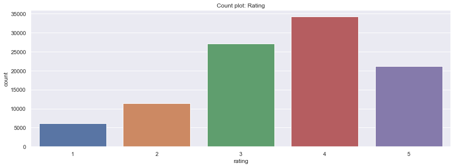

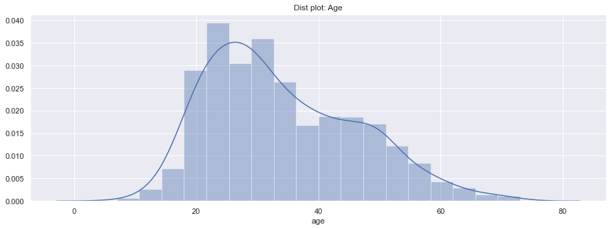

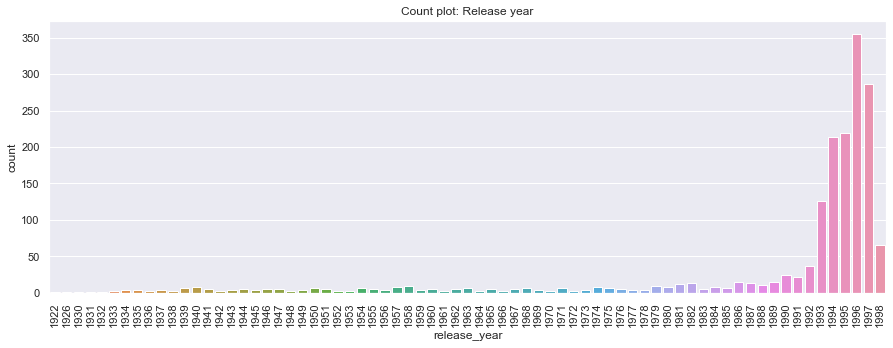

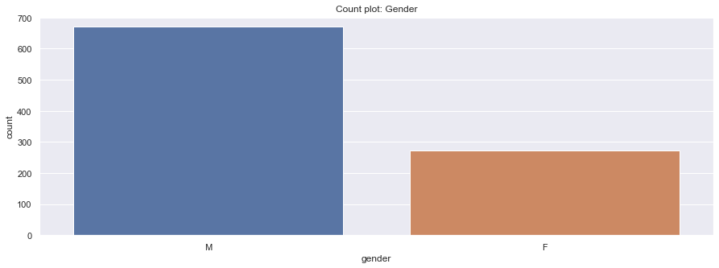

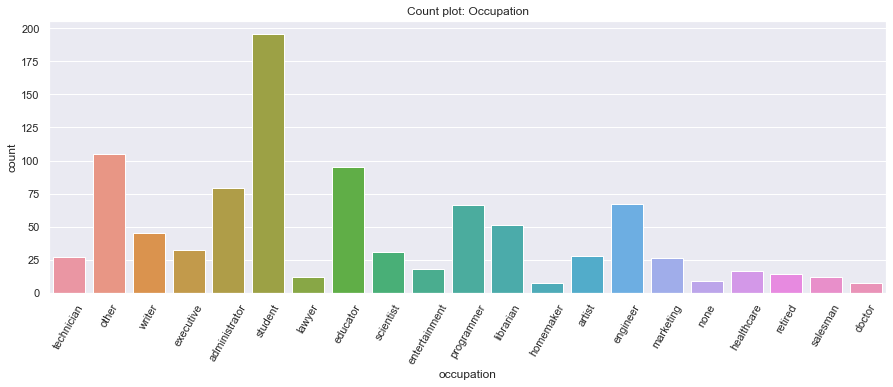

```python
#your code here
print("Univariante plots:rating, Age, release year, Gender and Occupation")

plt.figure(figsize=(15,5))  # set plot fig size
plt.title('Count plot: Rating')  # print plot title
sns.countplot(rating['rating']); # count plot for rating column

plt.figure(figsize=(15,5)) # set plot fig size
plt.title('Dist plot: Age')  # print plot title
sns.distplot(user['age']);  # dist plot for age column

movie['release_year']= movie['release date'].apply(lambda x: x.split('-')[2]) # split release date column to get year
plt.figure(figsize=(15,5))  # set plot fig size
plt.title('Count plot: Release year')  # print plot title
rel_year_plot = sns.countplot(movie['release_year']);  # count plot for release_year
rel_year_plot.set_xticklabels(rel_year_plot.get_xticklabels(),rotation=90);  # rotate x axis labels to 90 deg

plt.figure(figsize=(15,5))  # set plot fig size
plt.title('Count plot: Gender')  # print plot title
sns.countplot(user['gender']);  # count plot for gender column

plt.figure(figsize=(15,5)) # set plot fig size
plt.title('Count plot: Occupation')  # print plot title
occ_plot =sns.countplot(user['occupation'])  # count plot for occupation column
occ_plot.set_xticklabels(occ_plot.get_xticklabels(),rotation=60);  # rotate x axis labels to 60 deg
```

**Insights:**

```
1. There are more number 4 ratings.
2. Column Age is right skewed. More number of users are between 20-30 years age.
3. Number of movie release incresed from the year 1993. Maximum was in the year 1996.
4. There are more Males than females in the users data.
5. From the data, it looks like students watch more movies. Doctors watch less movies.
```

### 8. Visualize how popularity of genres has changed over the years - 10 marks

Note that you need to use the **percent of number of releases in a year** as a parameter of popularity of a genre

Hint 1: You need to reach to a data frame where the release year is the index and the genre is the column names (one cell shows the number of release in a year in one genre) or vice versa. (Drop unnecessary column if there are any)

Hint 2: Find the total number of movies release in a year(use item dataset to get count of movies released in a particular year, store that value in a new column as 'total'). Now divide the value of each genre in that year by total to get percentage number of release in a particular year. `(df.div(df['total'], axis= 0) * 100)`

Once that is achieved, you can either use univariate plots or can use the heatmap to visualise all the changes over the years in one go.

Hint 3: Use groupby on the relevant column and use sum() on the same to find out the number of releases in a year/genre.

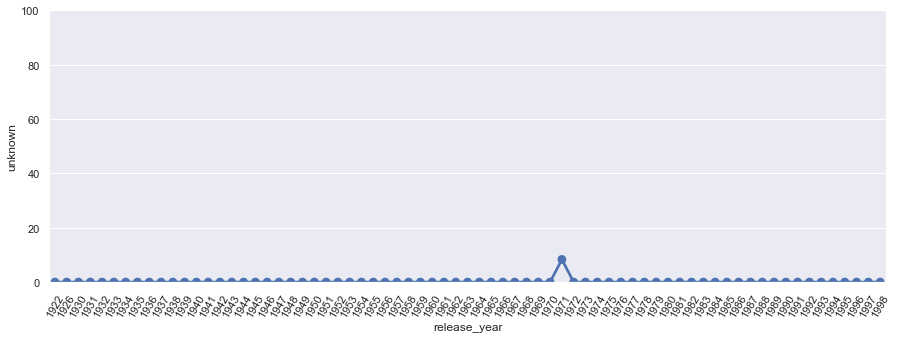

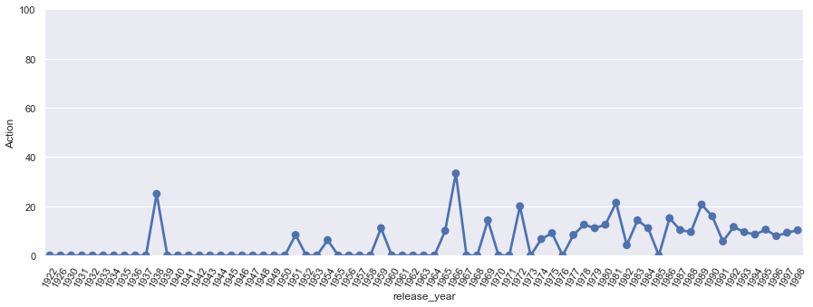

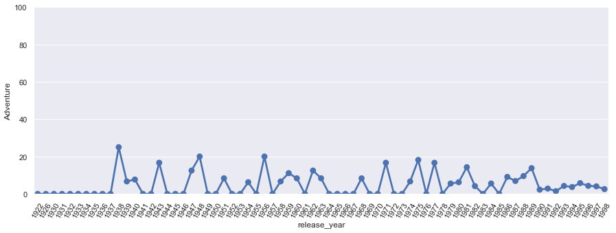

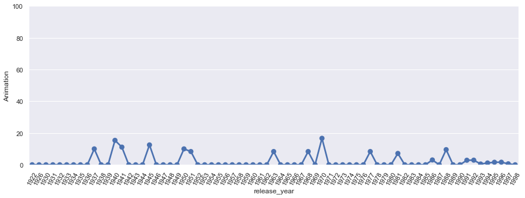

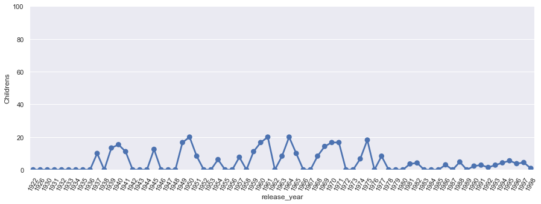

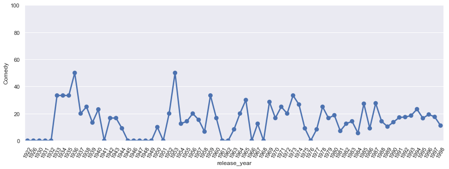

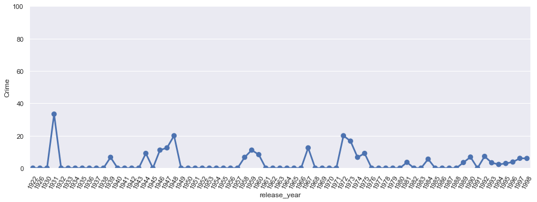

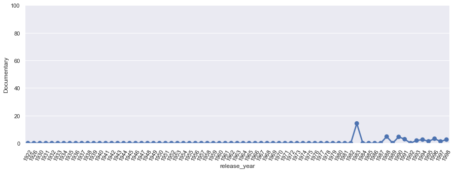

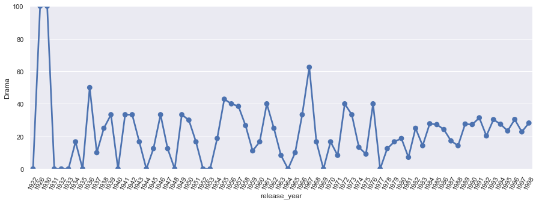

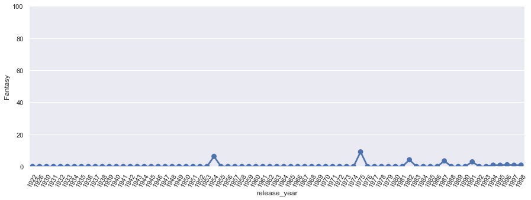

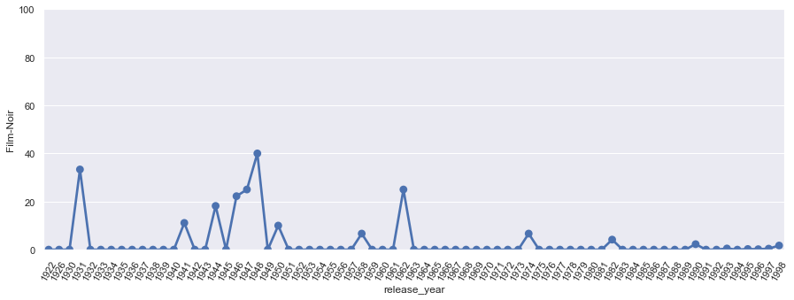

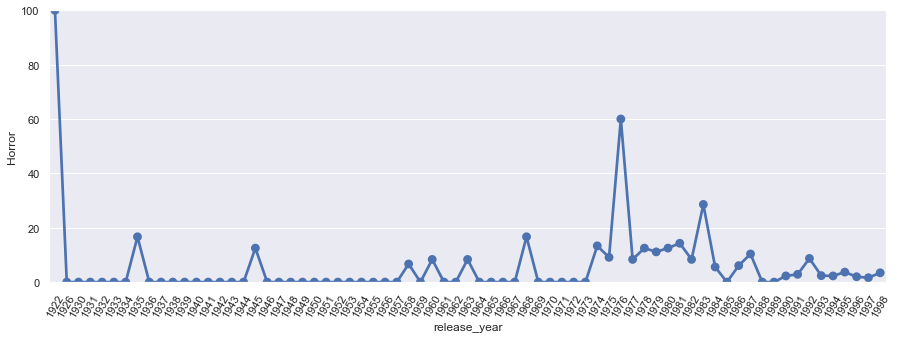

[7 more figures not shown]

```python
#your code here

genre_columns =['unknown', 'Action',
       'Adventure', 'Animation', 'Childrens', 'Comedy', 'Crime', 'Documentary',
       'Drama', 'Fantasy', 'Film-Noir', 'Horror', 'Musical', 'Mystery',
       'Romance', 'Sci-Fi', 'Thriller', 'War', 'Western'] #created list of genres column names to facilitate interation


movie_groupby = movie.groupby('release_year')[genre_columns].apply(sum,axis=0) # sum of movies per genre per year
movie_groupby['total'] = movie_groupby[genre_columns].apply(sum,axis=1)# total number of movie in one year

genre_percent = (movie_groupby[genre_columns].div(movie_groupby['total'], axis= 0) * 100)  #calculating percentage for each genre
genre_percent['release_year'] = genre_percent.index


for col in genre_columns:
    plt.figure(figsize=(15,5))  # set fig size
    plt.xticks(rotation = 60)   # rotate x axis labels to 60 deg
    g = sns.pointplot(x=genre_percent.index,y=col,data=genre_percent)
    g.set_ylim(0, 100)   # set all graphs with same y index to facilitate comparition.
```

**Insights:**

Insights on some of the major genres having more number of movie counts

1. Drame:  
   i) Looks like this genre appears to have popularity in early years between 1992 -1931.  
   ii) After that, this genre show decent popularity with few lows in between.  
   iii) But in recent years, the popularity numbers are incresing with no major down fall.
2. Action:  
   i) This genre shows least popularity in the early years (1992- 1936).  
   ii) There was a suggen spike in popularity between years(1937-1939).  
   iii) This genre popularity shows increase from 1976. (although there is fall again in the year 1985)
3. Comedy  
   i) After drama genre in line, Comedy genre shows huge popularity.  
   ii) Though there were lows in between years, this genre shows increase in percentage in between.

### 9. Find the top 25 movies in terms of average ratings for movies that have been rated more than 100 times - 10 marks

Hints :

1. Find the count of ratings and average ratings for every movie.
2. Slice the movies which have ratings more than 100.
3. Sort values according to average rating such that movie which highest rating is on top.
4. Select top 25 movies.
5. You will have to use the .merge() function to get the movie titles.

Note: This question will need you to research about groupby and apply your findings. You can find more on groupby on https://realpython.com/pandas-groupby/.

```python
#your code here

rating_copy = rating.copy()    # work on copy of pandas dataframe.
rating_copy['rating_avg'] = rating_copy['rating']
rating_copy['rating_count'] = rating_copy['rating']
rating_summary = rating_copy.groupby(by='movie id').agg({'rating_avg':'mean', 'rating_count':'count'}) # find mean and count of ratings
rating_count_gre_100 = rating_summary[rating_summary['rating_count']>100]  #slice movies which have ratings more than 100

rating_count_avg_sort = rating_count_gre_100.sort_values(by=['rating_avg'], ascending = False) # sort rating average in descending order
rating_output = rating_count_avg_sort.head(25).reset_index() #get top 25 movie ids

final_output = pd.merge(rating_output,movie[['movie id','movie title']], how='left', on = 'movie id') # merge with movie data to get movie titles
final_output
```

|  | movie id | rating_avg | rating_count | movie title |
| --- | --- | --- | --- | --- |
| 0 | 408 | 4.491071 | 112 | Close Shave, A |
| 1 | 318 | 4.466443 | 298 | Schindler's List |
| 2 | 169 | 4.466102 | 118 | Wrong Trousers, The |
| 3 | 483 | 4.456790 | 243 | Casablanca |
| 4 | 64 | 4.445230 | 283 | Shawshank Redemption, The |
| 5 | 603 | 4.387560 | 209 | Rear Window |
| 6 | 12 | 4.385768 | 267 | Usual Suspects, The |
| 7 | 50 | 4.358491 | 583 | Star Wars |
| 8 | 178 | 4.344000 | 125 | 12 Angry Men |
| 9 | 134 | 4.292929 | 198 | Citizen Kane |
| 10 | 427 | 4.292237 | 219 | To Kill a Mockingbird |
| 11 | 357 | 4.291667 | 264 | One Flew Over the Cuckoo's Nest |
| 12 | 98 | 4.289744 | 390 | Silence of the Lambs, The |
| 13 | 480 | 4.284916 | 179 | North by Northwest |
| 14 | 127 | 4.283293 | 413 | Godfather, The |
| 15 | 285 | 4.265432 | 162 | Secrets & Lies |
| 16 | 272 | 4.262626 | 198 | Good Will Hunting |
| 17 | 657 | 4.259542 | 131 | Manchurian Candidate, The |
| 18 | 474 | 4.252577 | 194 | Dr. Strangelove or: How I Learned to Stop Worr... |
| 19 | 174 | 4.252381 | 420 | Raiders of the Lost Ark |
| 20 | 479 | 4.251397 | 179 | Vertigo |
| 21 | 313 | 4.245714 | 350 | Titanic |
| 22 | 511 | 4.231214 | 173 | Lawrence of Arabia |
| 23 | 484 | 4.210145 | 138 | Maltese Falcon, The |
| 24 | 172 | 4.204360 | 367 | Empire Strikes Back, The |

### 10. Check for the validity of the below statements with respect to the data provided - 10 marks

- Men watch more drama than women
- Women watch more Sci-Fi than men
- Men watch more Romance than women

**compare the percentages**

**Please pay attention to what should be the denominator while calculating percentages**

1. Merge all the datasets
2. There is no need to conduct statistical tests around this. Just **compare the percentages** and comment on the validity of the above statements.
3. you might want ot use the .sum(), .div() function here.
4. Use number of ratings to validate the numbers. For example, if out of 4000 ratings received by women, 3000 are for drama, we will assume that 75% of the women watch drama.

```python
#your code here

#print(rating.columns,user.columns,movie.columns)

# merging data


merge1 = pd.merge(rating,user,how='left',on='user id')  # rating-user left join
merge2 = pd.merge(merge1,movie,how='left',on='movie id') # merge1(rating-user left join)-movie left join

merge2_groupby = merge2.groupby('gender')[genre_columns].apply(sum,axis=0)  # sum of ratings per gender per genre
merge2_groupby.loc['F','total_ratings'] = merge2['gender'].value_counts()['F'] # total number of ratings by Female
merge2_groupby.loc['M','total_ratings'] = merge2['gender'].value_counts()['M'] # total number of ratings by Male

merge2_gender_pert = merge2_groupby.copy() # work on copy of pandas dataframe.
merge2_gender_pert = merge2_gender_pert[genre_columns].div(merge2_gender_pert['total_ratings'],axis =0)*100  # find percentage of each genre for male and female

print(merge2_gender_pert.T)
```

```
gender               F          M
unknown       0.000000   0.001347
Action       21.142191  27.130353
Adventure    12.202797  14.290331
Animation     3.865579   3.514678
Childrens     8.671329   6.665769
Comedy       31.344211  29.307837
Crime         6.969697   8.431188
Documentary   0.726496   0.768920
Drama        42.766123  38.899811
Fantasy       1.410256   1.331807
Film-Noir     1.495726   1.815244
Horror        4.650350   5.548074
Musical       5.602176   4.729329
Mystery       5.104895   5.293563
Romance      22.758353  18.318072
Sci-Fi       10.213675  13.602208
Thriller     19.759130  22.604363
War           8.504274   9.707783
Western       1.441336   1.997037
```

**Conclusion:**

**1. Men watch more drama than women**  
This statement looks False.  
Women drama % - 42.76612276612276  
Men drama % - 38.89981147320226  
So Women watch more drama than men

**2. Women watch more Sci-Fi than men**  
This statement is False as per the data  
Women Sci-Fi % - 10.213675  
Men Sci-Fi % - 13.602208  
So Men watch more Sci-Fi than women

**3. Men watch more Romance than women**  
This statement is False as per the data  
Women Romance % - 22.758353  
Men Romance % - 18.318072  
So Women watch more Romance than men

```python
#Other approach : Results are same.


merge1 = pd.merge(rating,user,how='left',on='user id')
merge2 = pd.merge(merge1,movie,how='left',on='movie id')
# Validation of merge , one id is missing so few columns have NaN value
merge2.isna().sum()


total_women_ratings = merge2['gender'].value_counts()['F'] # number of ratings by women
total_men_ratings = merge2['gender'].value_counts()['M']  # number of ratings by men
print('Total ratings received by women :',total_women_ratings)
print('Total ratings received by men :',total_men_ratings)
print('\n\n')


#1. Men watch more drama than women

women_for_drama = merge2.groupby('gender').sum()['Drama']['F'] # number of ratings by women for Drama
men_for_drama = merge2.groupby('gender').sum()['Drama']['M']  # number of ratings by men for Drama
print('Number of drama ratings by women',women_for_drama)
print('Number of drama ratings by men',men_for_drama)

women_drame_percent = (women_for_drama/total_women_ratings)*100  # find
men_drame_percent = (men_for_drama/total_men_ratings)*100
print('women_drame_percent',women_drame_percent)  # women drama percent
print('men_drame_percent',men_drame_percent)      # men drama percent
print('\n')


#2. Women watch more Sci-Fi than men

women_for_SciFi = merge2.groupby('gender').sum()['Sci-Fi']['F']   # number of ratings by women for Sci-Fi
men_for_SciFi = merge2.groupby('gender').sum()['Sci-Fi']['M']      # number of ratings by men for Sci-Fi
print('Number of Sci-Fi ratings by women',women_for_SciFi)
print('Number of Sci-Fi ratings by men',men_for_SciFi)

women_SciFi_percent = (women_for_SciFi/total_women_ratings)*100
men_SciFi_percent = (men_for_SciFi/total_men_ratings)*100
print('women_SciFi_percent',women_SciFi_percent)     # women SciFi percent
print('men_SciFi_percent',men_SciFi_percent)      # men SciFi percent
print('\n')


#3. Men watch more Romance than women

women_for_romance = merge2.groupby('gender').sum()['Romance']['F']  # number of ratings by women for Romance
men_for_romance = merge2.groupby('gender').sum()['Romance']['M']    ## number of ratings by men for Romance
print('Number of Romance ratings by women',women_for_romance)
print('Number of Romance ratings by men',men_for_romance)

women_romance_percent = (women_for_romance/total_women_ratings)*100  # women romance percent
men_romance_percent = (men_for_romance/total_men_ratings)*100     # men romance percent
print('women_romance_percent',women_romance_percent)
print('men_romance_percent',men_romance_percent)
print('\n')
```

```
Total ratings received by women : 25740
Total ratings received by men : 74260



Number of drama ratings by women 11008.0
Number of drama ratings by men 28887.0
women_drame_percent 42.76612276612276
men_drame_percent 38.89981147320226


Number of Sci-Fi ratings by women 2629.0
Number of Sci-Fi ratings by men 10101.0
women_SciFi_percent 10.213675213675213
men_SciFi_percent 13.602208456773498


Number of Romance ratings by women 5858.0
Number of Romance ratings by men 13603.0
women_romance_percent 22.75835275835276
men_romance_percent 18.31807164018314
```

**Conclusion:**

**1. Men watch more drama than women**  
This statement looks False.  
Women drama % - 42.76612276612276  
Men drama % - 38.89981147320226  
So Women watch more drama than men

**2. Women watch more Sci-Fi than men**  
This statement is False as per the data  
Women Sci-Fi % - 10.213675  
Men Sci-Fi % - 13.602208  
So Men watch more Sci-Fi than women

**3. Men watch more Romance than women**  
This statement is False as per the data  
Women Romance % - 22.758353  
Men Romance % - 18.318072  
So Women watch more Romance than men